# Cancer Evenness Replication

Benjamin Cocanougher

August 19, 2015

```r
suppressMessages(require(RColorBrewer))
```

## Introduction:

Large epidemiological datasets are available for analyzing the types and rates of cancer worldwide. This analysis will attempt to apply information theory to epidemiology.

I will be using equations derived by [Thomas Schneider](http://alum.mit.edu/www/toms) to calculate the equivalent of ecological evenness. In this analysis I am considering the population to be cancer types and number of individual species in the population to be number of cases of each cancer type.

## Data Analysis:

The data used for this analysis comes from the [International Agency for Research on Cancer](http://ci5.iarc.fr/CI5I-X/Pages/download.aspx). Specifically we will look at the most recent volume X data. The Volume X data can be downloaded from the IARC by clicking [here](http://ci5.iarc.fr/CI5-X/CI5-Xd.zip). The data from the downloaded file will contain a larger number of small .csv files.

The huge list of .csv files in the IARC data was converted to a single .csv file using the following unix command after changing to the directory containing the files:

cat *.csv > CI5Xd.csv

(The files can also be read directly into R, but it is much slower.)

You can either collapse the files together yourself using the above command, or grab the combined files from the [github repo](https://github.com/bcoke/Cancer-Evenness).

First we need to read the data into R.

```r
# You will need to edit this to the working

# directory containing the CI5Xd.csv file
setwd("/Users/bencocanougher/Desktop/")

if (!exists("cancerX")) {
  cancerX <- read.csv("CI5Xd.csv")
}

colnames(cancerX) <- c("sex", "cancerSite", "ageGroup",
                       "numberOfCases", "PersonYearsAtRisk")

str(cancerX)
```

```
## 'data.frame':    7844111 obs. of  5 variables:
##  $ sex              : int  1 1 1 1 1 1 1 1 1 1 ...
##  $ cancerSite       : int  1 1 1 1 1 1 1 1 1 1 ...
##  $ ageGroup         : int  2 3 4 5 6 7 8 9 10 11 ...
##  $ numberOfCases    : int  23 38 56 72 64 86 102 131 168 221 ...
##  $ PersonYearsAtRisk: int  454935 414130 467301 340529 288300 234561 214254 210409 184422 81751 ...
```

GetEvenness function is defined:

```r
GetEvenness <- function(vector) {
  n <- sum(vector)
  s <- length(vector)
  #print("", quote = F)
  #print(c("sum:",n), quote = F)
  #print(c("s:",s), quote = F)
  # Basharin's small-sample correction:
  ens <- (s-1)/(2*log(2)*n);
  H <- -sum((vector/n)*log2(vector/n)) + ens
  Hmax <- log2(s)
  H/Hmax
  #print(c("evenness:", round(H/Hmax,3)), quote = F)
}
```

A description of the code describing the cancerSite integers can be found [here](http://ci5.iarc.fr/CI5I-X/Pages/cancer_vol10.aspx). It is a list of ICD-10 codes that were converted to the cancerSite vector identifiers. These idenfiers include several many summation codes, and thus must be subset appropriately.

## Evenness of 15 Organ Categories is near 80%

The following code chunk subsets the ID codes into 15 big categories, which correspond to cancer incidence at the organ level.

```r
# Helper Function
CancerCleaning <- function(site) {
  which(cancerX$cancerSite == site)
}

# vector to be used in function
vector <- c(3, 22, 72, 89, 99, 107, 113, 114, 149,
            159, 173, 199, 212, 242, 243)

# Create the desired data frame outside of the function
z <- unlist(lapply(vector, CancerCleaning))
cancerX2 <- cancerX[z, c(2:4)]

CancerEvennessX <- function(ageGroupID) {
  # First subset the cancer data frame by the ageGroup column
  x <- cancerX2[cancerX2$ageGroup == ageGroupID, ]

  # str(x)

  # Then sum all of the data by cancer type
  x2 <- aggregate(. ~ cancerSite, data = x, FUN=sum)

  # str(x2)

  # Remove cancer types with no data (non-existant
  # species in population of interest)
  x3 <- x2$numberOfCases[which(x2$numberOfCases != 0)]

  # str(x3)

  # Calculate the evenness and print to the console
  x4 <- GetEvenness(x3)
  print(paste0("Evenness of Age Group ", ageGroupID," = ", x4), quote = FALSE)
  x4
}

x <- unlist(lapply(1:19, CancerEvennessX))
```

```
## [1] Evenness of Age Group 1 = 0.648442713060927
## [1] Evenness of Age Group 2 = 0.591522069571527
## [1] Evenness of Age Group 3 = 0.685671364183226
## [1] Evenness of Age Group 4 = 0.780131914954125
## [1] Evenness of Age Group 5 = 0.830107652812051
## [1] Evenness of Age Group 6 = 0.866675837885188
## [1] Evenness of Age Group 7 = 0.872988014539238
## [1] Evenness of Age Group 8 = 0.855287996620204
## [1] Evenness of Age Group 9 = 0.836012323237511
## [1] Evenness of Age Group 10 = 0.835191184309397
## [1] Evenness of Age Group 11 = 0.839214219702342
## [1] Evenness of Age Group 12 = 0.830575194970572
## [1] Evenness of Age Group 13 = 0.814759416263448
## [1] Evenness of Age Group 14 = 0.801584087337845
## [1] Evenness of Age Group 15 = 0.798440288169883
## [1] Evenness of Age Group 16 = 0.801842761787105
## [1] Evenness of Age Group 17 = 0.805383686557899
## [1] Evenness of Age Group 18 = 0.803176251377235
## [1] Evenness of Age Group 19 = 0.773868929441008
```

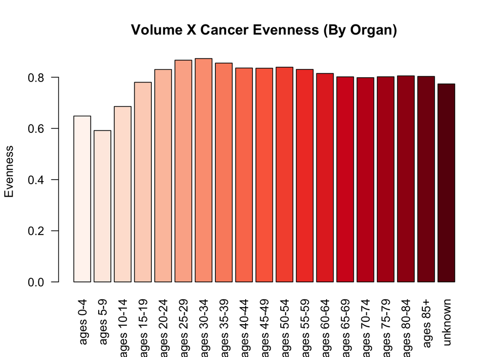

```r
par(las=2) #rotates x-axis labels
barplot(x,
        col = colorRampPalette(brewer.pal(9,"Reds"))(19),
        main = "Volume X Cancer Evenness (By Organ)",
        ylab = "Evenness",
        names.arg = c("ages 0-4","ages 5-9",
                      "ages 10-14","ages 15-19",
                      "ages 20-24","ages 25-29",
                      "ages 30-34","ages 35-39",
                      "ages 40-44","ages 45-49",
                      "ages 50-54","ages 55-59",
                      "ages 60-64","ages 65-69",
                      "ages 70-74","ages 75-79",
                      "ages 80-84","ages 85+",
                      "unknown")
        )
```

## Evenness of 69 Cancer Subtypes is near 70%

This code chunk subsets the data to look not at 15 categories of cancer, but at each of the 69 individual cancer subtypes available in the data.

```r
# Helper Function
CancerCleaning <- function(site) {
  which(cancerX$cancerSite == site)
}

# vector to be used in function
vector <- c(4, 5, 8, 13, 16, 17, 18, 19, 20, 21, 23, 35, 41, 42, 48, 49, 50, 58, 68, 69, 70, 71, 73, 74, 75, 76, 77, 86, 87, 88, 89, 100, 106, 108, 109, 110, 11, 112, 113, 115, 116, 117, 125, 132, 133, 145, 148, 150, 151, 152, 158, 160, 161, 162, 163, 172, 174, 183, 184, 200, 210, 211, 213, 217, 224, 225, 226, 242, 243)

# Create the desired data frame outside of the function
z <- unlist(lapply(vector, CancerCleaning))
cancerX2 <- cancerX[z, c(2:4)]

CancerEvennessX <- function(ageGroupID) {
  # First subset the cancer data frame by the ageGroup column
  x <- cancerX2[cancerX2$ageGroup == ageGroupID, ]

  # str(x)

  # Then sum all of the data by cancer type
  x2 <- aggregate(. ~ cancerSite, data = x, FUN=sum)

  # str(x2)

  # Remove cancer types with no data (non-existant
  # species in population of interest)
  x3 <- x2$numberOfCases[which(x2$numberOfCases != 0)]

  # str(x3)

  # Calculate the evenness and print to the console
  x4 <- GetEvenness(x3)
  print(paste0("Evenness of Age Group ", ageGroupID," = ", x4), quote = FALSE)
  x4
}

x <- unlist(lapply(1:19, CancerEvennessX))
```

```
## [1] Evenness of Age Group 1 = 0.518958765092867
## [1] Evenness of Age Group 2 = 0.520307462273511
## [1] Evenness of Age Group 3 = 0.598742178869825
## [1] Evenness of Age Group 4 = 0.661810063142057
## [1] Evenness of Age Group 5 = 0.688683516618552
## [1] Evenness of Age Group 6 = 0.709474889904872
## [1] Evenness of Age Group 7 = 0.721213204849441
## [1] Evenness of Age Group 8 = 0.721086399677296
## [1] Evenness of Age Group 9 = 0.720915494073223
## [1] Evenness of Age Group 10 = 0.729127261731701
## [1] Evenness of Age Group 11 = 0.737577218077924
## [1] Evenness of Age Group 12 = 0.722731344909576
## [1] Evenness of Age Group 13 = 0.704512415746358
## [1] Evenness of Age Group 14 = 0.694755434093302
## [1] Evenness of Age Group 15 = 0.697112296996015
## [1] Evenness of Age Group 16 = 0.705901867585838
## [1] Evenness of Age Group 17 = 0.718995594914796
## [1] Evenness of Age Group 18 = 0.729574872741235
## [1] Evenness of Age Group 19 = 0.673668561981316
```

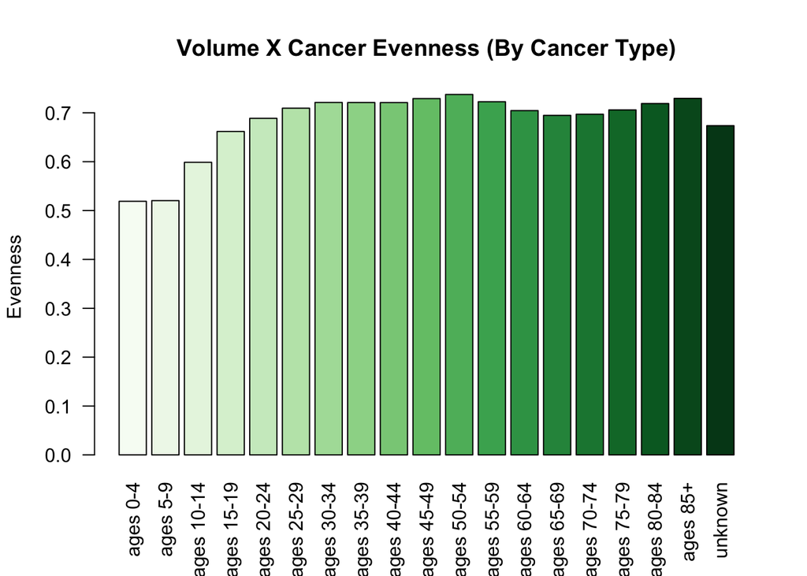

```r
par(las=2) #rotates x-axis labels
barplot(x,
        col = colorRampPalette(brewer.pal(9,"Greens"))(19),
        main = "Volume X Cancer Evenness (By Cancer Type)",
        ylab = "Evenness",
        names.arg = c("ages 0-4","ages 5-9",
                      "ages 10-14","ages 15-19",
                      "ages 20-24","ages 25-29",
                      "ages 30-34","ages 35-39",
                      "ages 40-44","ages 45-49",
                      "ages 50-54","ages 55-59",
                      "ages 60-64","ages 65-69",
                      "ages 70-74","ages 75-79",
                      "ages 80-84","ages 85+",
                      "unknown")
        )
```